# simple_curve_fitting

Milla Juntunen

2022-07-15

*** CURVE FITTING & SIMULATING NEW DATA ***

This code tries to fit different curves in the existing data about prehospital blood transfusion’s effect on mortality rate, pick up the model that is considered the best one and then simulate new data points.

This is done separately to all blood products. At the end all products are combined to see if it makes any difference.

All results are plotted below.

```r
source("simulating_timepoints.R")
```

```r
library("readxl")
library("ggplot2")
library("dplyr")
library("npreg")
# Reading the data from excel (time in minutes)
df <- read_excel("C:\\Projektit\\whole_blood_research\\excel\\Emergencyprocess_PHBT_splines.xlsx", sheet = "all_min")
```

Simulating new data points. For more information, see simulating_timepoints.Rmd

```r
# Making simulated data
simulated_times <- make_timepoints.function(20)
```

[output not shown]

[output cut: 44 more lines]

```
##
## Chart A is the chart to follow
## Patient transported to Shock Room!
## 68.66099 is the total time from the 'Risk Analysis'
## 25.95892 is the total time from the 'Infusion Starts'
##
## Chart B is the chart to follow
## Patient transported to Shock Room!
## 87.40262 is the total time from the 'Risk Analysis'
## 19.83401 is the total time from the 'Infusion Starts'
##
## Chart A is the chart to follow
## Patient transported to Shock Room!
## 71.45992 is the total time from the 'Risk Analysis'
## 41.15676 is the total time from the 'Infusion Starts'
```

*** PRCBs ***

Filtering different blood products from the data. Trying first with PRBCs (packed red blood cells).

```r
# Filtering rows by products (only some of them are useful at a time)
PRBCS_data <- filter(df, products == "O-negative PRBCs" )
print(PRBCS_data)
```

```
## # A tibble: 5 × 5
##   Article                              `Link to source` products  time mortality
##   <chr>                                <chr>            <chr>    <dbl>     <dbl>
## 1 Civilian prehrefospital transfusion… https://onlinel… O-negat…  1440      16.1
## 2 <NA>                                 <NA>             O-negat… 10080      21.4
## 3 <NA>                                 <NA>             O-negat… 43200      21.4
## 4 Mortality of civilian patients with… https://www.ncb… O-negat…   360      10
## 5 <NA>                                 <NA>             O-negat… 40320      26
```

Testing different models to see which one is the best fit.

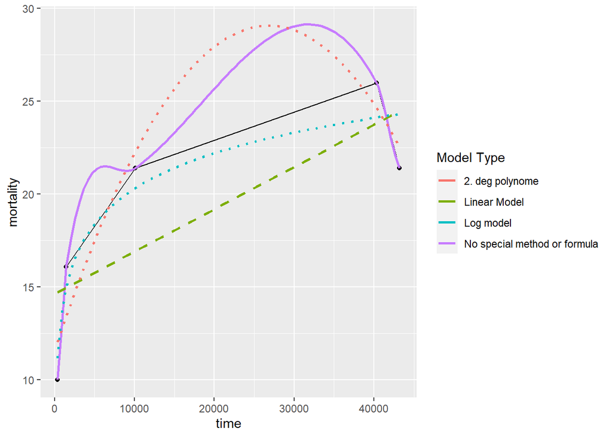

```r
ggplot(PRBCS_data, aes(x = time, y = mortality) ) +
    geom_point() +
    geom_line() +
    geom_smooth(aes(color="No special method or formula"), se = FALSE,  linetype = 1) +
    geom_smooth(method="lm", aes(color="Linear Model"), formula= (y ~ x), se = FALSE, linetype = 2) +
    geom_smooth(method="lm", aes(color="2. deg polynome"), formula= (y ~ poly(x,2)), se = FALSE, linetype = 3) +
    geom_smooth(method = "lm", aes(color="Log model"), formula = y ~ log(x), se = FALSE, linetype = 3) +
    guides(color = guide_legend("Model Type"))
```

It seems that the logarithmic curve could be the best one, so using it to simulate new data.

Simulating new data points. Forcing the curve to start from 0 (at that time it is assumed that everyone is still alive.). Adding some noise to the simulated data at the same time.

```r
# Predicting new points
my_model <- lm(mortality~0+log(time), data = PRBCS_data)
variable_time <- data.frame(time=simulated_times)
predicted_y <- predict(object = my_model, newdata = variable_time)

# Adding some noise to predicted_y
for(i in 1:length(predicted_y)){
  predicted_y[i] <- rnorm(1, predicted_y[i],1)
}

# Making combined dataframe from original and simulated data
original.data <- data.frame(time = PRBCS_data$time, mortality = PRBCS_data$mortality)
simulation.data <- data.frame(time = simulated_times, mortality = predicted_y)
all.data <- rbind(original.data, simulation.data)
```

Plotting the results about PRCBs, curves with raw data, simulated data and with both points combined.

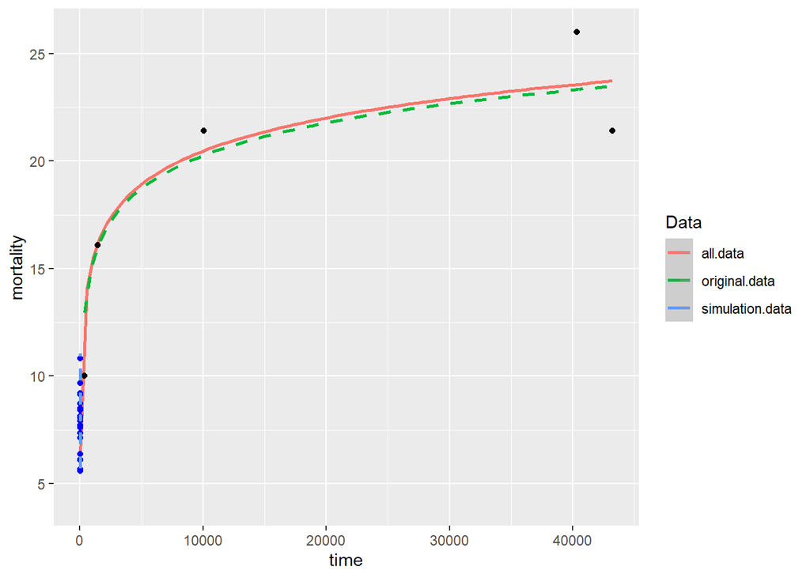

```r
# Plotting the combined data and the simulated and original points (O-neg PRBCs)
ggplot(all.data, aes(x = time, y = mortality))+
  geom_smooth(method = "lm", aes(color="all.data"), formula = y~0+log(x), se = FALSE, linetype = 1)+
  geom_point(data = original.data) +
  geom_smooth(data = original.data, method = "lm", aes(color="original.data"), formula = y~0+log(x), se = FALSE, linetype = 2) +
  geom_point(data = simulation.data, color = "blue")+
  geom_smooth(data = simulation.data, aes(x = simulated_times, y = predicted_y, color = "simulation.data"), linetype = 2)+
  guides(color = guide_legend("Data"))
```

*** PRBCS AND/OR PLASMA ***

Done as above, changing product.

```r
# Filtering PRBCS_and_plasma_data:
PRBCS_and_plasma_data <- filter(df, products == "plasma and/or RBCs" )
print(PRBCS_and_plasma_data)
```

```
## # A tibble: 5 × 5
##   Article                              `Link to source` products  time mortality
##   <chr>                                <chr>            <chr>    <dbl>     <dbl>
## 1 Pre-hospital transfusion of plasma … https://www.ncb… plasma …   360      13.3
## 2 <NA>                                 <NA>             plasma …  1440      16
## 3 Multicenter Observational Prehospit… https://www.ncb… plasma …   180      16.2
## 4 <NA>                                 <NA>             plasma …  1440      19
## 5 <NA>                                 <NA>             plasma … 43200      25.4
```

```r
# Making simulated data (using same simulated time points as earlier)
my_model <- lm(mortality~0+log(time), data = PRBCS_and_plasma_data)
variable_time <- data.frame(time=simulated_times)
predicted_y <- predict(object = my_model, newdata = variable_time)

# Adding some noise to predicted_y
for(i in 1:length(predicted_y)){
  predicted_y[i] <- rnorm(1, predicted_y[i],1)
}
# Making combined data frame from original and simulated data
original.data <- data.frame(time = PRBCS_and_plasma_data$time, mortality = PRBCS_and_plasma_data$mortality)
simulation.data <- data.frame(time = simulated_times, mortality = predicted_y)
all.data <- rbind(original.data, simulation.data)
```

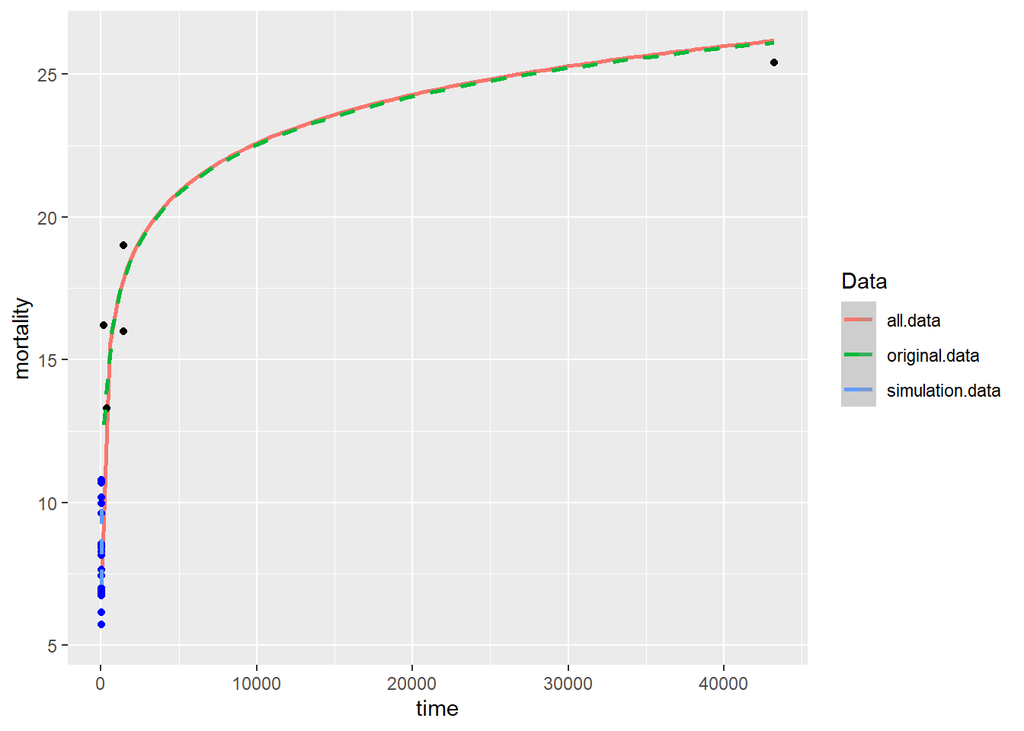

```r
# Plotting the combined data and the simulated and original points (plasma and/or RCBs)
ggplot(all.data, aes(x = time, y = mortality))+
  geom_smooth(method = "lm", aes(color="all.data"), formula = y~0+log(x), se = FALSE, linetype = 1)+
  geom_point(data = original.data) +
  geom_smooth(data = original.data, method = "lm", aes(color="original.data"), formula = y~0+log(x), se = FALSE, linetype = 2) +
  geom_point(data = simulation.data, color = "blue")+
  geom_smooth(data = simulation.data, aes(x = simulated_times, y = predicted_y, color = "simulation.data"), linetype = 2)+
  guides(color = guide_legend("Data"))
```

Combination of red blood cells and plasma is the only product that has higher than 25% mortality according to these plots, the simulated time points have also the greatest distribution compared to other products…

*** WHOLE BLOOD *** Done as above, changing product.

Had an issue with negative mortality rates near zero at first, but it was solved by forcing the intercept to 0. However, this made the curve a lot lower, which might be problematic.

```r
# Filtering whole blood:
WB_data <- filter(df, products == "LTOWB" )
print(WB_data)
```

```
## # A tibble: 7 × 5
##   Article                              `Link to source` products  time mortality
##   <chr>                                <chr>            <chr>    <dbl>     <dbl>
## 1 Prehospital whole blood reduces ear… https://pubmed.… LTOWB      360      16.8
## 2 <NA>                                 <NA>             LTOWB     1440      22.4
## 3 Clinical outcomes among low-titer g… https://pubmed.… LTOWB      360       3
## 4 <NA>                                 <NA>             LTOWB     1440       8.9
## 5 Injured recipients of low-titer gro… https://pubmed.… LTOWB      360       4.4
## 6 <NA>                                 <NA>             LTOWB     1440      14.1
## 7 <NA>                                 <NA>             LTOWB    43200      34.8
```

```r
# Making simulated data (using same simulated time points as earlier)
my_model <- lm(mortality~0+log(time), data = WB_data)
variable_time <- data.frame(time=simulated_times)
predicted_y <- predict(object = my_model, newdata = variable_time)

# Adding some noise to predicted_y
for(i in 1:length(predicted_y)){
  predicted_y[i] <- rnorm(1, predicted_y[i],1)
}
# Making combined data frame from original and simulated data
original.data <- data.frame(time = WB_data$time, mortality = WB_data$mortality)
simulation.data <- data.frame(time = simulated_times, mortality = predicted_y)
all.data <- rbind(original.data, simulation.data)
```

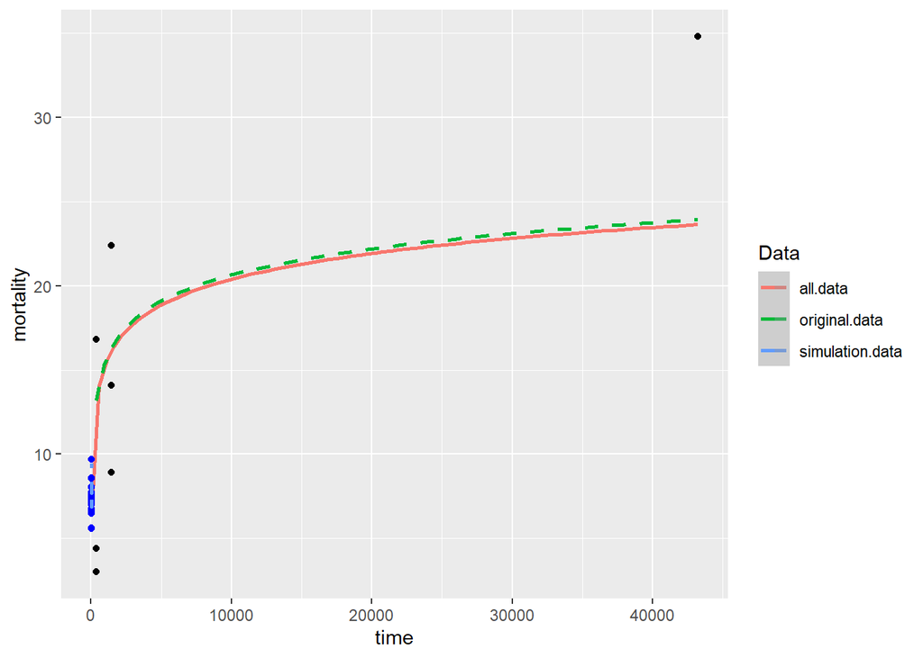

```r
# Plotting the combined data and the simulated and original points (WB)
ggplot(all.data, aes(x = time, y = mortality))+
  geom_smooth(method = "lm", aes(color="all.data"), formula = y~0+log(x), se = FALSE, linetype = 1)+
  geom_smooth(data = original.data, method = "lm", aes(color="original.data"), formula = y~0+log(x), se = FALSE, linetype = 2) +
  geom_point(data = original.data) +
  geom_point(data = simulation.data, color = "blue")+
  geom_smooth(data = simulation.data, aes(x = simulated_times, y = predicted_y, color = "simulation.data"), linetype = 2)+
  guides(color = guide_legend("Data"))
```

*** ALL PRODUCTS COMBINED ***

```r
all_products <- filter(df, products == "O-negative PRBCs" | products == "LTOWB" | products == "plasma and/or RBCs")
print(all_products)
```

```
## # A tibble: 17 × 5
##    Article                             `Link to source` products  time mortality
##    <chr>                               <chr>            <chr>    <dbl>     <dbl>
##  1 Civilian prehrefospital transfusio… https://onlinel… O-negat…  1440      16.1
##  2 <NA>                                <NA>             O-negat… 10080      21.4
##  3 <NA>                                <NA>             O-negat… 43200      21.4
##  4 Pre-hospital transfusion of plasma… https://www.ncb… plasma …   360      13.3
##  5 <NA>                                <NA>             plasma …  1440      16
##  6 Mortality of civilian patients wit… https://www.ncb… O-negat…   360      10
##  7 <NA>                                <NA>             O-negat… 40320      26
##  8 Multicenter Observational Prehospi… https://www.ncb… plasma …   180      16.2
##  9 <NA>                                <NA>             plasma …  1440      19
## 10 <NA>                                <NA>             plasma … 43200      25.4
## 11 Prehospital whole blood reduces ea… https://pubmed.… LTOWB      360      16.8
## 12 <NA>                                <NA>             LTOWB     1440      22.4
## 13 Clinical outcomes among low-titer … https://pubmed.… LTOWB      360       3
## 14 <NA>                                <NA>             LTOWB     1440       8.9
## 15 Injured recipients of low-titer gr… https://pubmed.… LTOWB      360       4.4
## 16 <NA>                                <NA>             LTOWB     1440      14.1
## 17 <NA>                                <NA>             LTOWB    43200      34.8
```

```r
# Making simulated data (using same simulated time points as earlier)
my_model <- lm(mortality~0+log(time), data = all_products)
variable_time <- data.frame(time=simulated_times)
predicted_y <- predict(object = my_model, newdata = variable_time)

# Adding some noise to predicted_y
for(i in 1:length(predicted_y)){
  predicted_y[i] <- rnorm(1, predicted_y[i],1)
}
# Making combined data frame from original and simulated data
original.data <- data.frame(time = all_products$time, mortality = all_products$mortality)
simulation.data <- data.frame(time = simulated_times, mortality = predicted_y)
all.data <- rbind(original.data, simulation.data)
```

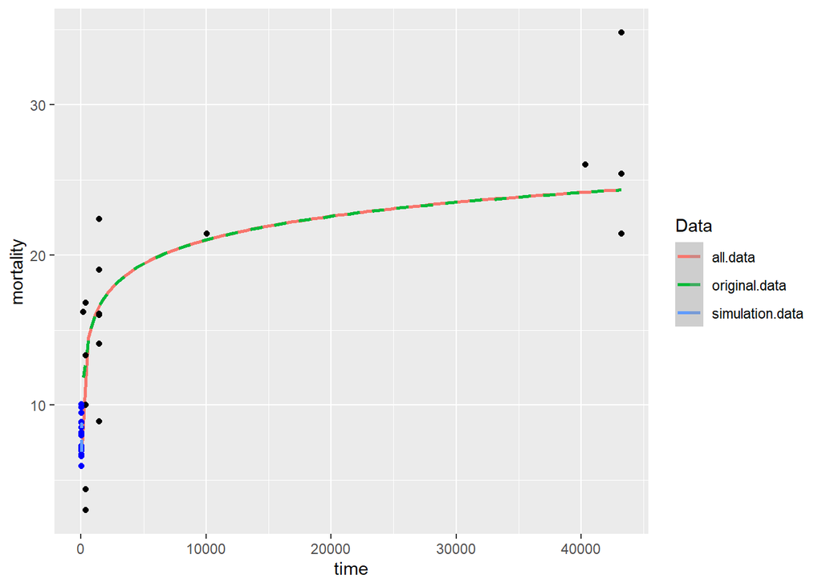

```r
# Plotting the combined data and the simulated and original points
ggplot(all.data, aes(x = time, y = mortality))+
  geom_smooth(method = "lm", aes(color="all.data"), formula = y~0+log(x), se = FALSE, linetype = 1)+
  geom_smooth(data = original.data, method = "lm", aes(color="original.data"), formula = y~0+log(x), se = FALSE, linetype = 2) +
  geom_point(data = original.data) +
  geom_point(data = simulation.data, color = "blue")+
  geom_smooth(data = simulation.data, aes(x = simulated_times, y = predicted_y, color = "simulation.data"), linetype = 2)+
  guides(color = guide_legend("Data"))
```

Well, this seems similar to the others. Since the number of data points is so small and the results between different products are quite close to each other, decided to concentrate on getting the best fit to all data points available using other modelling methods (see for example trying_glm.Rmd).